# Homework 14

Itzel Gonzalez

2025-03-03

## Instructions

Answer the following questions and complete the exercises in RMarkdown. Please embed all of your code and push your final work to your repository. Your final lab report should be organized, clean, and run free from errors. Remember, you must remove the `#` for the included code chunks to run. Be sure to add your name to the author header above.

Make sure to use the formatting conventions of RMarkdown to make your report neat and clean!

## Load the libraries

```r
library(tidyverse)
library(janitor)
library(shiny)
library(shinydashboard)
library(shinythemes)
```

## Load the data

For this assignment, we will use the built-in mammals sleep dataset. The data are from: V. M. Savage and G. B. West. A quantitative, theoretical framework for understanding mammalian sleep. Proceedings of the National Academy of Sciences, 104 (3):1051-1056, 2007.

```r
msleep <- msleep %>% clean_names()
```

1. Explore the data set. What are the column names?

```r
summary(msleep)
```

```
##      name              genus               vore              order
##  Length:83          Length:83          Length:83          Length:83
##  Class :character   Class :character   Class :character   Class :character
##  Mode  :character   Mode  :character   Mode  :character   Mode  :character
##
##
##
##
##  conservation        sleep_total      sleep_rem      sleep_cycle
##  Length:83          Min.   : 1.90   Min.   :0.100   Min.   :0.1167
##  Class :character   1st Qu.: 7.85   1st Qu.:0.900   1st Qu.:0.1833
##  Mode  :character   Median :10.10   Median :1.500   Median :0.3333
##                     Mean   :10.43   Mean   :1.875   Mean   :0.4396
##                     3rd Qu.:13.75   3rd Qu.:2.400   3rd Qu.:0.5792
##                     Max.   :19.90   Max.   :6.600   Max.   :1.5000
##                                     NA's   :22      NA's   :51
##      awake          brainwt            bodywt
##  Min.   : 4.10   Min.   :0.00014   Min.   :   0.005
##  1st Qu.:10.25   1st Qu.:0.00290   1st Qu.:   0.174
##  Median :13.90   Median :0.01240   Median :   1.670
##  Mean   :13.57   Mean   :0.28158   Mean   : 166.136
##  3rd Qu.:16.15   3rd Qu.:0.12550   3rd Qu.:  41.750
##  Max.   :22.10   Max.   :5.71200   Max.   :6654.000
##                  NA's   :27
```

**The column names are: name, genus, vore,order, conservation, sleep_total, sleep_rem, sleep_cycle, awake, brainwt, and bodywt.**

```r
colnames(msleep)
```

```
##  [1] "name"         "genus"        "vore"         "order"        "conservation"
##  [6] "sleep_total"  "sleep_rem"    "sleep_cycle"  "awake"        "brainwt"
## [11] "bodywt"
```

2. Make a boxplot of the total sleep time for each type of vore diet. Try using some aesthetics to make the plot look nice, including a fill by vore.

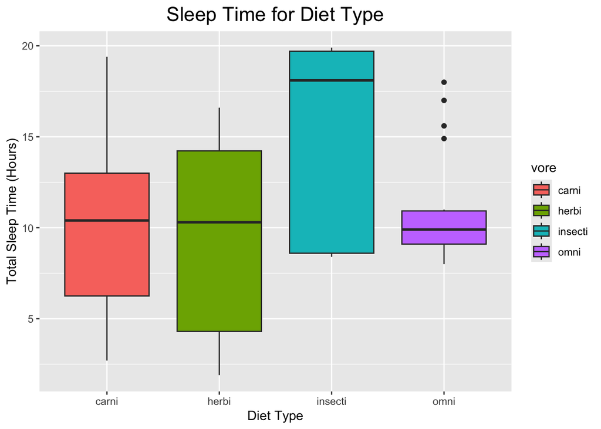

```r
msleep %>%
  drop_na(vore) %>%
  ggplot(aes(x=vore, y=sleep_total, fill = vore))+
  geom_boxplot()+
  labs(title = "Sleep Time for Diet Type", x="Diet Type", y="Total Sleep Time (Hours)")+
  theme(plot.title = element_text(size = rel(1.5), hjust = 0.5))
```

3. The boxplot is fine, but we can build in reactivity so that every variable related to sleep can be explored. These variables include: sleep_total, sleep_rem, sleep_cycle, and awake. Create a shiny app that allows the user to select the variable of interest and then displays a boxplot by type of vore.

```r
library(shiny)

ui <- fluidPage(
    selectInput("y",
                "Select Sleep Variable",
                choices = c("sleep_total", "sleep_rem", "sleep_cycle", "awake"),
                selected = "sleep_total"),

    plotOutput("plot", width="600px", height="500px")
)

server <- function(input, output, session) {
  session$onSessionEnded(stopApp)

  output$plot <- renderPlot({
    msleep %>%
      drop_na(vore) %>%
      ggplot(aes_string(x="vore", y=input$y, fill="vore"))+
      geom_boxplot()+
      labs(title = "Sleep Variable for Vore Types", x="Diet Type", y=input$y)+
      theme(plot.title = element_text(size = rel(1.5), hjust = 0.5))
  })
}


shinyApp(ui, server)
```

4. Make a density plot that shows the distribution of the total sleep time for each type of vore diet. Try using some aesthetics to make the plot look nice, including a fill by vore.

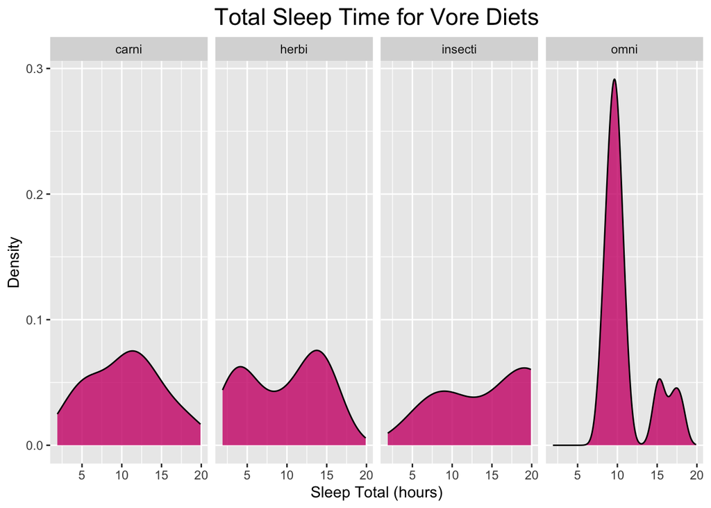

```r
msleep %>%
  drop_na(vore) %>%
  ggplot(aes(x=sleep_total))+
  geom_density(fill="deeppink3", alpha = 0.8)+
  facet_grid(.~vore)+
  labs(title = "Total Sleep Time for Vore Diets", x= "Sleep Total (hours)", y="Density")+
theme(plot.title = element_text(size = rel(1.5), hjust = 0.5))
```

5. The density plot is fine, but we can build in reactivity so that the user can select each vore type. Create a shiny app that allows the user to select the vore type of interest and then displays a density plot of the total sleep time.

```r
library(shiny)

ui <- fluidPage(
  selectInput("x",
                "Select Vore Type",
                choices = c("carni", "herbi", "insecti", "omni"),
                selected = "carni"),

    plotOutput("plot", width="600px", height="500px")
)

server <- function(input, output, session) {
  session$onSessionEnded(stopApp)

  output$plot <- renderPlot({
    msleep %>%
      filter(vore==input$x) %>%
      ggplot(aes(sleep_total))+
      geom_density(fill='deeppink3', alpha = 0.8)+
      labs(title = "Total Sleep Time for Vore Type", x="Total Sleep Time (Hours)", y="Density")+
      theme(plot.title = element_text(size = rel(1.5), hjust = 0.5))

  })

}
shinyApp(ui, server)
```